# verlet_integration_for_jumping

```python
import matplotlib.pyplot as plt
import numpy as np

plt.style.use('ggplot')
PAD = .3
```

## Create Our Character's Path in Space

The first thing that we would like to do is create a path in space that our character will take, given three things that we would like to control:

- height at the apex of the jump
- the horizontal distance at the apex of the jump
- the maximum speed that the user can travel

Below I also included some initial conditions that we can play around with to make sure that our equations work anywhere in our video game's space/time.

```python
t_initial = 0 # initial time of jump (seconds)
x_initial = 0 # initial horizontal position of jump (pixels)
y_initial = 0 # initial vertical position of jump (pixels)
# For these, you are assuming a jump from (0,0)
h = 5         # height at apex of jump (pixels)
x_h = 5       # horizontal distance at apex (pixels)
v_x = 2       # max speed user can travel (pixels/sec)
```

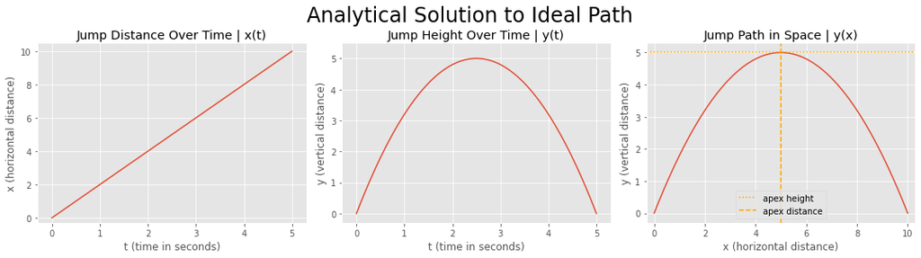

```python
v_0 = (2*h*v_x)/x_h      # from that video
g = (-2*h*v_x**2)/x_h**2 # from that video

t_final = (2 * x_h) / v_x + t_initial
t = np.linspace(t_initial, t_final, 1000)
x = (t - t_initial) * v_x + x_initial
y_t = .5*g*(t - t_initial)**2 + v_0*(t - t_initial) + y_initial
y_x = .5*g*((x - x_initial)/v_x)**2 + v_0*((x - x_initial)/v_x) + y_initial

fig, ax = plt.subplots(1,3,figsize=(15,4))
fig.suptitle('Analytical Solution to Ideal Path', size=24)
fig.tight_layout()

ax[0].set_title('Jump Distance Over Time | x(t)')
ax[0].plot(t, x)
ax[0].set_xlim([t_initial - PAD, t_final + PAD])
ax[0].set_ylim([x_initial - PAD, 2*x_h + .2 + x_initial + PAD])
ax[0].set_xlabel('t (time in seconds)')
ax[0].set_ylabel('x (horizontal distance)')

ax[1].set_title('Jump Height Over Time | y(t)')
ax[1].plot(t, y_t)
ax[1].set_xlim([t_initial - PAD, t_final + PAD])
ax[1].set_ylim([y_initial - PAD, h+.2 + y_initial + PAD])
ax[1].set_xlabel('t (time in seconds)')
ax[1].set_ylabel('y (vertical distance)')

ax[2].set_title('Jump Path in Space | y(x)')
ax[2].plot(x, y_x)
ax[2].axhline(y=h+y_initial, color='orange', linestyle=':',label='apex height')
ax[2].axvline(x=x_h+x_initial, color='orange', linestyle='--', label='apex distance')
ax[2].set_xlim([x_initial-PAD, 2*x_h + x_initial+PAD ])
ax[2].set_ylim([y_initial-PAD, h+y_initial+PAD])
ax[2].legend()
ax[2].set_xlabel('x (horizontal distance)')
ax[2].set_ylabel('y (vertical distance)')
plt.show()
```

Just so we're on the same page: the graph on the left is showing the horizontal distance (in pixels) over time. The graph in the center is showing the character's height (in pixels) over time. The 3rd graph is showing the path that the character will take in space, but contains no information about time. This last one can be thought of as a combination of the first two, where you simply plot the jump distance on the x-axis and the height on the y-axis. This was a subtle shift that they used in the video, since you are plotting y as a function of x. But we know that x is a function of time as well.

## Aproximate this path using Verlet Integration

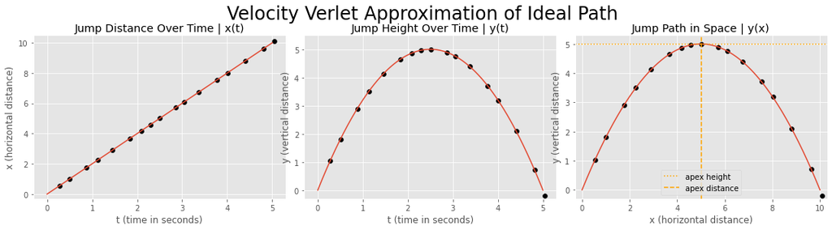

```python
# initialize everything that will be incremented in the loop
t_current = t_initial
x_pos = x_initial
y_pos = y_initial
x_vel = v_x
y_vel = v_0



fig, ax = plt.subplots(1,3,figsize=(15,4))

while (t_current < t_final):
    t_elapsed = np.random.normal(.25, .075, 1)     # random time has passed
    x_pos += x_vel*t_elapsed                      # assuming that the x_velocity remains v_x throught the jump
    y_pos += y_vel*t_elapsed + .5*g*t_elapsed**2
    x_vel += 0
    y_vel += g*t_elapsed
    t_current += t_elapsed
    ax[0].scatter(t_current, x_pos, color='k')
    ax[1].scatter(t_current, y_pos, color='k')
    ax[2].scatter(x_pos, y_pos, color='k')

fig.suptitle('Velocity Verlet Approximation of Ideal Path', size=24)
fig.tight_layout()

ax[0].set_title('Jump Distance Over Time | x(t)')
ax[0].plot(t, x)
ax[0].set_xlim([t_initial - PAD, t_final + PAD])
ax[0].set_ylim([x_initial - PAD, 2*x_h + .2 + x_initial + PAD])
ax[0].set_xlabel('t (time in seconds)')
ax[0].set_ylabel('x (horizontal distance)')

ax[1].set_title('Jump Height Over Time | y(t)')
ax[1].plot(t, y_t)
ax[1].set_xlim([t_initial - PAD, t_final + PAD])
ax[1].set_ylim([y_initial - PAD, h+.2 + y_initial + PAD])
ax[1].set_xlabel('t (time in seconds)')
ax[1].set_ylabel('y (vertical distance)')

ax[2].set_title('Jump Path in Space | y(x)')
ax[2].plot(x, y_x)
ax[2].axhline(y=h+y_initial, color='orange', linestyle=':',label='apex height')
ax[2].axvline(x=x_h+x_initial, color='orange', linestyle='--', label='apex distance')
ax[2].set_xlim([x_initial-PAD, 2*x_h + x_initial+PAD ])
ax[2].set_ylim([y_initial-PAD, h+y_initial+PAD])
ax[2].legend()
ax[2].set_xlabel('x (horizontal distance)')
ax[2].set_ylabel('y (vertical distance)')
plt.show()
```

The black dots in the above plots represent the position of our character at every frame. Notice that since our acceleration is constant, there will be no error. Also notice that although there is no error, the spacing between the dots is not constant, because we allowed a slightly varied amount of time to pass between each time step.